# Homeschooling

# Introduction

Homeschooling is often misunderstood, as is shown in the following meme:

[figure not shown]

In this report, we explore homeschooling and how homeschooling and non-homeschooling families compare.

## What is Homeschooling?

If you consider yourself a homeschooler, then the answer might seem obvious. However, there are significant differences in what is called homeschooling. In my experience, the following are called homeschooling:

- Public and private schools putting their lectures and classrooms online
- Parents/relatives/tutors following an entire purchased curriculum
- Parents/relatives/tutors teaching the same “pod” of students for full-time school hours.
- Parents combining part-time online classes, homeschooling co-ops, private tutoring, reading books, watching videos, field trips, etc.

The main differences are in:

- Who decides the curriculum
- Who does the teaching

In this study, [students are considered homeschooled](https://nces.ed.gov/fastfacts/display.asp?id=91) if their parents reported them as homeschooled, their enrollment in public or private schools did not exceed 24 hours per week, and they were not homeschooled due to a temporary illness.

## Data

Data came from the (USA) [National Center for Education Statistics 2019 Parent and Family Involvement in Education (PFI) Survey](https://nces.ed.gov/nhes/dataproducts.asp#2019dp)  
This survey is given by the US Census Bureau en every 4 years; the [next one is in 2023](https://www.census.gov/programs-surveys/nhes.html) while the [data will be available in late 2024](https://nces.ed.gov/nhes/).

We chose data from the census study, even though the data is four years old, to get a lower bound on the rate of homeschooling. Homeschooling is most likely under-reported to the government. Other data sources such as [National Home Education Research Institute](https://www.nheri.org/how-many-homeschool-students-are-there-in-the-united-states-during-the-2021-2022-school-year/) and [Homeschool Legal Defense Association](https://hslda.org/post/census-data-shows-phenomenal-homeschool-growth) could have more accurate predictions, but they have incentives to report high homeschooling rates.

The Covid-19 pandemic data (that is not included here) may skew the results The [US Census Bureau](https://www.census.gov/library/stories/2021/03/homeschooling-on-the-rise-during-covid-19-pandemic.html) reported that, between the spring of 2020 and the beginning of the new school year later that fall, the number of homeschooling families had doubled, to 11.1 percent of all US households. It is unclear how much of this trend has maintained.

## Historical Context

[figure not shown]

### Homeschooling is Not Just a Modern Trend

Homeschooling has been practiced since the 17th century, when Europeans began colonizing and settling in North America. Due to the lack of schools, parents had to assume the teaching role themselves or hire a private tutor. The founders of Plymouth Colony in 1620 required all parents to teach their children to read and write.

### Public Education Became Available

*“Not until the latter part of the 19th century, however, did public elementary schools become available to all children in nearly all parts of the country. In 1830, about 55% of children aged 5 to 14 were enrolled in public schools; by 1870, this figure had risen to about 78%.”* [Center for Educational Policy](https://files.eric.ed.gov/fulltext/ED606970.pdf). The first compulsory universal public education law went into effect in Massachusetts in 1852. Mississippi was the last state to pas a law requiring school attendance in 1917.

### Legality of Homeschooling

Less than 10 years later in 1925, the US Supreme Court ruled that [private schools could not be outlawed](https://web.archive.org/web/20060118165335/https://www.oyez.org/oyez/resource/case/449/) . However, every state in the U.S. has compulsory attendence laws that require that students be educated. Some states consider homeschooling programs to legally be private schools. Others have specific homeschooling requirements. Since 1993, homeschooling has been legal in all 50 states.

## Rate of Homeschooling

This shows the trend in homeschooling rates over the years. This trend may be lower than the actual rate due to homeschooling parents being less likely to fill out governmental forms. For more information on other estimates, see [How Many Homeschool Students are there in the United States during the 2021-2022 School Year?](https://www.nheri.org/how-many-homeschool-students-are-there-in-the-united-states-during-the-2021-2022-school-year)

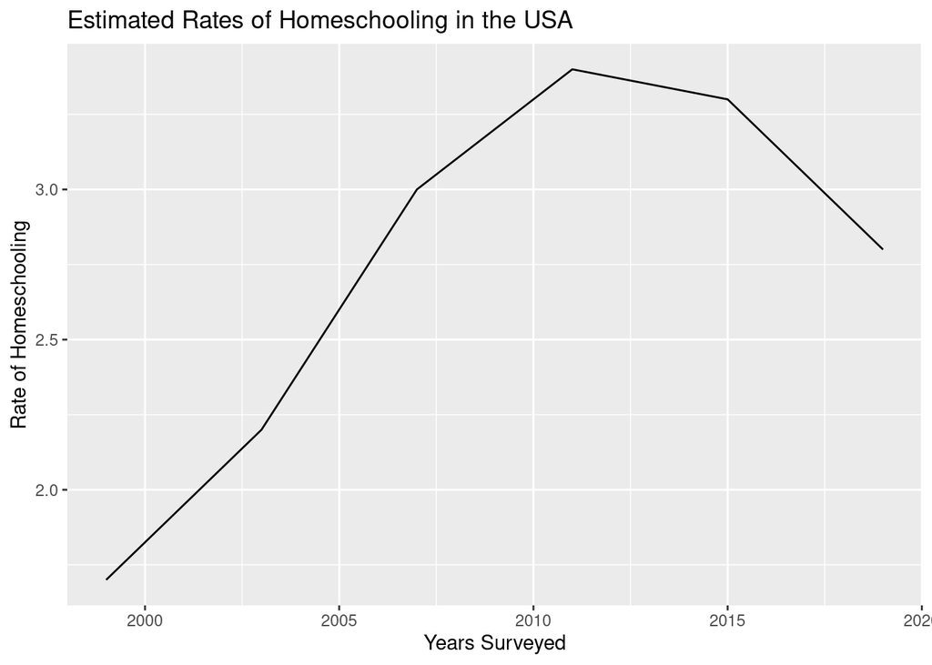

# Reasons for Homeschooling

Parents decide to home school their children for many different reasons. Here are the top reasons parents gave in 2019.

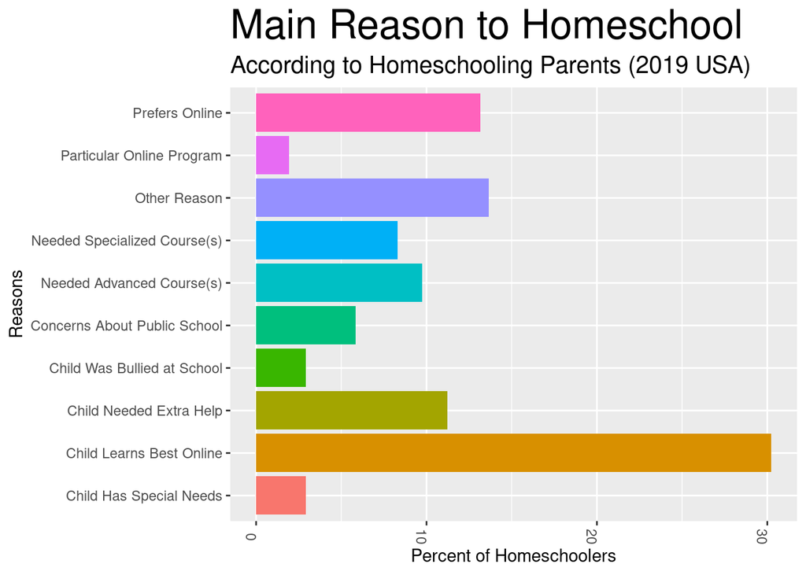

# Aspects of Homeschooling Families

How do homeschooling families look the same/different from non-homeschooling families?

## Size of Family

Note that the survey data had a maximum value of 5, although the shape of the homeschooling children density seems to indicate that there should be more children.

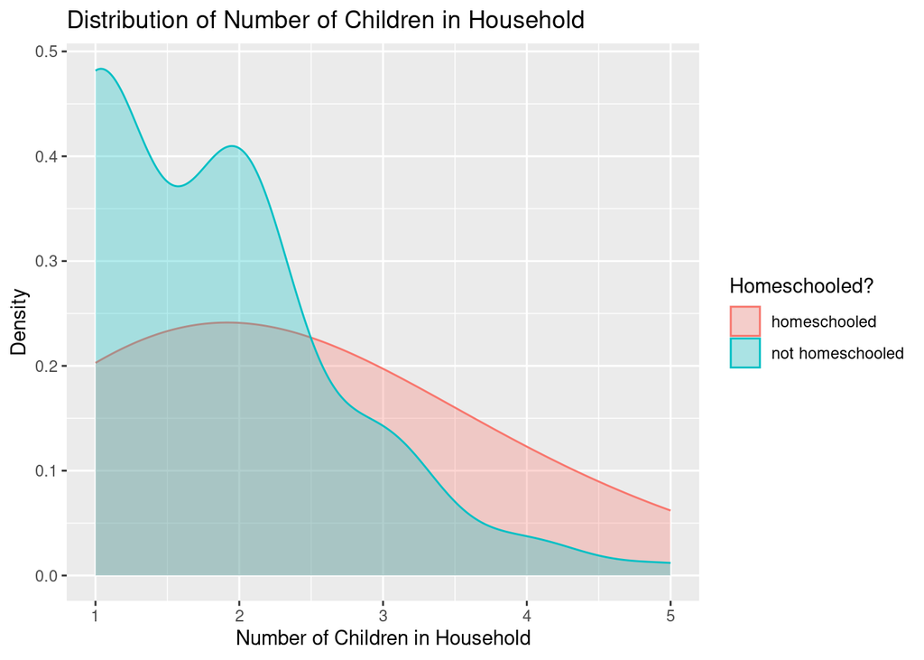

Parents have many different reasons for homeschooling, including dissatisfaction with public school academics. However, this does not seem to change the distribution of the primary teacher for homeschooled children.

## Primary Teacher

The colors emphasize the same grade level as the x-axis.

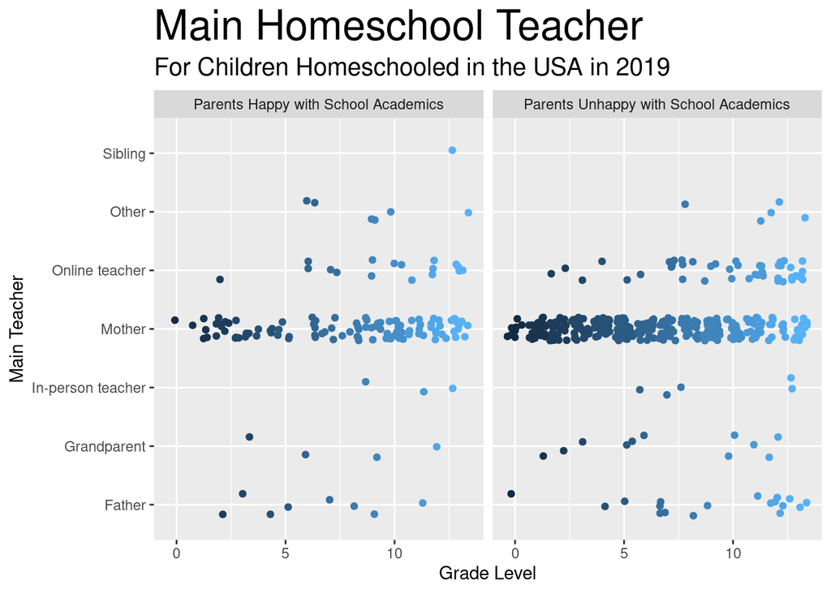

## Household Income

Homeschooling families have a wide spread of household income.

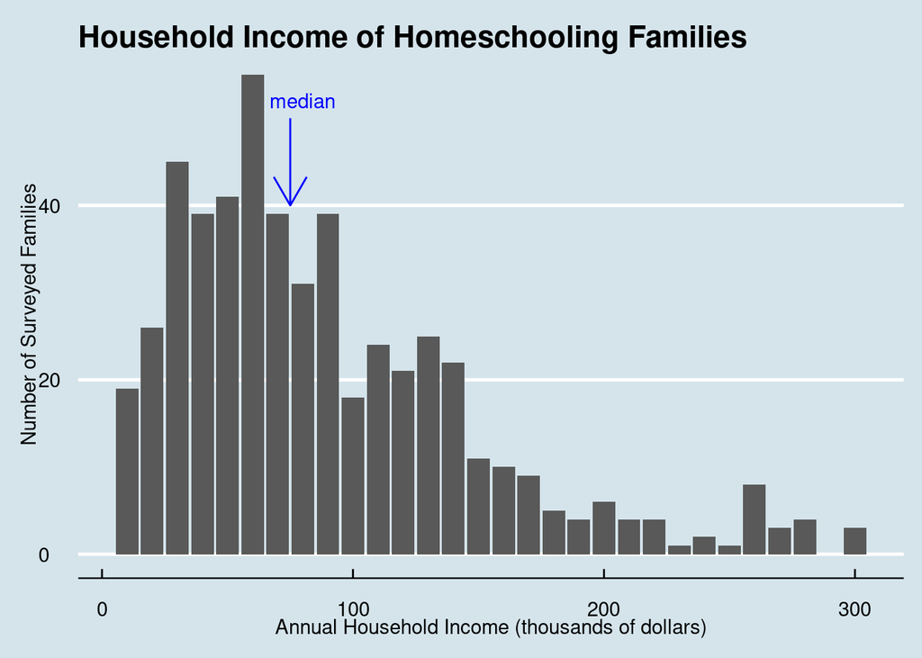

# Conclusion

Problems with this study:

- Homeschooling has different definitions to different people.
- We chose government databases to get a lower bound on homeschooling rates. Due to fear of government interference in their homeschooling program, homeschoolers seem less likely to return the surveys.